# Laboratorio 6 - Modsim

## Parte 3

Tiene la tarea de modelar el crecimiento de la población en múltiples escalas, desde organismos individuales hasta la población global. Para esto debe implementar un modelo multiescala en Python para analizar el crecimiento poblacional y su impacto.

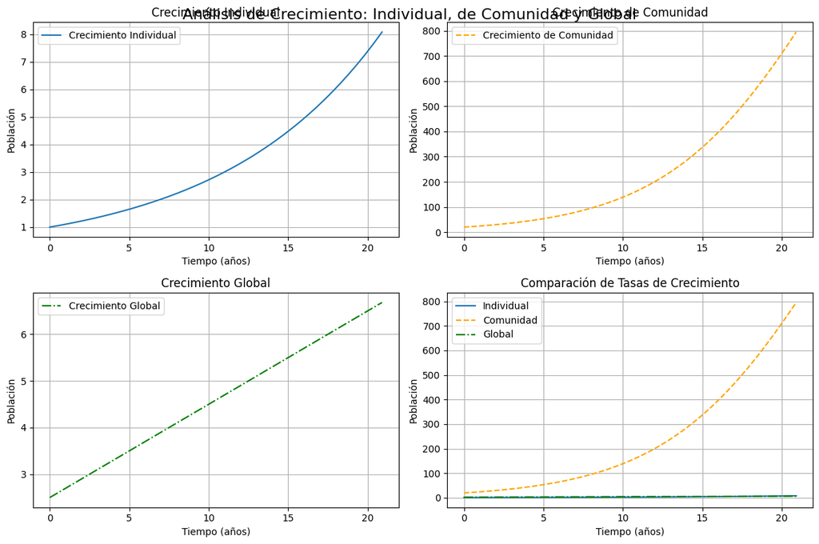

```python
import numpy as np
import matplotlib.pyplot as plt

t_individual = np.arange(0, 21, 0.1)
r_individual = 0.1
N0_individual = 1
t_comunidad = np.arange(0, 21, 0.1)
r_comunidad = 0.2
K_comunidad = 2000
N0_comunidad = 20

años_global = np.arange(0, 21, 0.1)
poblacion_global = [2.5 + i * 0.2 for i in años_global]

N_individual = N0_individual * np.exp(r_individual * t_individual)
N_comunidad = K_comunidad / (1 + ((K_comunidad - N0_comunidad) / N0_comunidad) * np.exp(-r_comunidad * t_comunidad))

fig, axes = plt.subplots(2, 2, figsize=(12, 8))

axes[0, 0].plot(t_individual, N_individual, label='Crecimiento Individual', linestyle='-')
axes[0, 0].set_xlabel('Tiempo (años)')
axes[0, 0].set_ylabel('Población')
axes[0, 0].legend()
axes[0, 0].grid(True)
axes[0, 0].set_title('Crecimiento Individual')
axes[0, 1].plot(t_comunidad, N_comunidad, label='Crecimiento de Comunidad', linestyle='--', color='orange')
axes[0, 1].set_xlabel('Tiempo (años)')
axes[0, 1].set_ylabel('Población')
axes[0, 1].legend()
axes[0, 1].grid(True)
axes[0, 1].set_title('Crecimiento de Comunidad')
axes[1, 0].plot(años_global, poblacion_global, label='Crecimiento Global', linestyle='-.', color='green')
axes[1, 0].set_xlabel('Tiempo (años)')
axes[1, 0].set_ylabel('Población')
axes[1, 0].legend()
axes[1, 0].grid(True)
axes[1, 0].set_title('Crecimiento Global')
axes[1, 1].plot(t_individual, N_individual, label='Individual', linestyle='-')
axes[1, 1].plot(t_comunidad, N_comunidad, label='Comunidad', linestyle='--', color='orange')
axes[1, 1].plot(años_global, poblacion_global, label='Global', linestyle='-.', color='green')
axes[1, 1].set_xlabel('Tiempo (años)')
axes[1, 1].set_ylabel('Población')
axes[1, 1].legend()
axes[1, 1].grid(True)
axes[1, 1].set_title('Comparación de Tasas de Crecimiento')
plt.tight_layout()
plt.suptitle('Análisis de Crecimiento: Individual, de Comunidad y Global', fontsize=16)
plt.show()
```

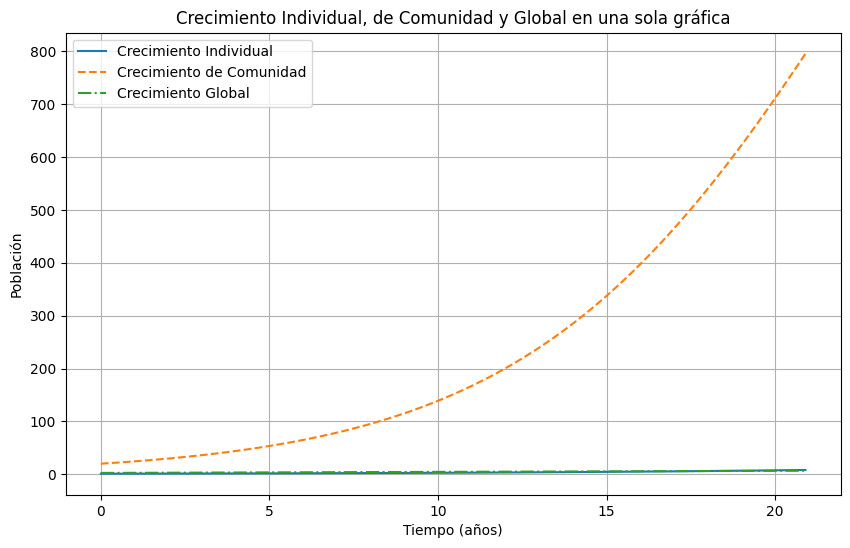

```python
plt.figure(figsize=(10, 6))
plt.plot(t_individual, N_individual, label='Crecimiento Individual', linestyle='-')
plt.plot(t_comunidad, N_comunidad, label='Crecimiento de Comunidad', linestyle='--')
plt.plot(años_global, poblacion_global, label='Crecimiento Global', linestyle='-.')
plt.xlabel('Tiempo (años)')
plt.ylabel('Población')
plt.legend()
plt.grid(True)
plt.title('Crecimiento Individual, de Comunidad y Global en una sola gráfica')
plt.show()
```

**a. ¿Qué es el modelado multiescala y por qué es esencial para comprender sistemas complejos como el crecimiento de la población?**

La modelización multiescala implica la representación y simulación de sistemas complejos en diversos niveles de detalle, que van desde lo microscópico hasta lo macroscópico. Este enfoque es fundamental para comprender fenómenos como el crecimiento de la población, ya que estos sistemas están influenciados por una variedad de factores en diferentes escalas. Al adoptar esta metodología, podemos capturar las interacciones y dinámicas que tienen lugar a nivel individual, comunitario y global, lo que facilita una comprensión más completa de cómo estos sistemas evolucionan con el tiempo.

**b. Describe el modelo a nivel individual en esta simulación multiescala. ¿Qué factores se consideran a escala individual?**

El modelo a nivel individual representa el crecimiento de la población de un solo individuo. En este caso, se utiliza la ecuación de crecimiento exponencial para modelar el crecimiento individual. Los factores considerados a esta escala son:  
r_individual: La tasa de crecimiento del individuo.  
N0_individual: La población inicial del individuo.  
t_individual: El tiempo en años.

**c. Discuta el modelo a escala de comunidad local. ¿Cómo incorpora interacciones entre individuos y factores ambientales?**

r_comunidad: La tasa de crecimiento de la comunidad.  
K_comunidad: La capacidad de carga de la comunidad, que representa el límite superior de población que el entorno puede sostener.  
N0_comunidad: La población inicial de la comunidad.  
t_comunidad: El tiempo en años.  
La ecuación logística incorpora la competencia intraespecífica, donde a medida que la población se acerca a la capacidad de carga, el crecimiento se desacelera debido a la competencia por recursos limitados.

**d. Explique el modelo a escala global. ¿Qué parámetros y factores se consideran al modelar toda la población mundial?**

Los parámetros y factores considerados al modelar toda la población mundial son:  
años_global: El tiempo en años.  
poblacion_global: Una lista que representa el crecimiento global de la población en función del tiempo.  
En este nivel, no se incorporan interacciones detalladas ni factores específicos, ya que se trata de una representación simplificada de la población global que solo muestra un crecimiento lineal uniforme a lo largo del tiempo.